# Project - Bank Churn Prediction

## Model Building (10 points)

- Build Deep Neural Network

**Model-1**

- We will use a simple NN made of 4 fully-connected layers with ReLu activation. The NN takes a vector of length 7 as input. This represents the information related to each transactions, ie each line with 7 columns from the dataset. For each transaction, the final layer will output a probability distribution (sigmoid activation function) and classify either as Non-Exited (0) or Exited (1).
- a dropout step is included to prevent overfitting.

*Dropout*

Dropout is a regularization technique for neural network models proposed by Srivastava, et al. in their 2014 paper Dropout: A Simple Way to Prevent Neural Networks from Overfitting. Dropout is a technique where randomly selected neurons are ignored during training. They are “dropped-out” randomly.

**Creating a model**

- Keras model object can be created with Sequential class
- At the outset, the model is empty per se. It is completed by adding additional layers and compilation

```python
#Initialize the model
from tensorflow.keras.models import Sequential
model = Sequential()
```

**Adding layers [layers and activations]**

- Keras layers can be added to the model
- Adding layers are like stacking lego blocks one by one
- By trying different architectures to get the best result
- It should be noted that as this is a classification problem, sigmoid layer (softmax for multi-class problems) should be added

```python
# This adds the input layer (by specifying input dimension) AND the first hidden layer (units)
from keras.layers import Dense, Dropout
model.add(Dense(units=5, input_dim = 7,activation='relu'))   # input of 7 columns as shown above
# hidden layer
model.add(Dense(units=8,activation='relu'))
#Adding Dropout to prevent overfitting
model.add(Dropout(0.5))
model.add(Dense(8,activation='relu'))
# Adding the output layer -- Notice that we do not need to specify input dim.
# we have an output of 1 node, which is the the desired dimensions of our output (exited or not)
# We use the sigmoid because we want probability outcomes
model.add(Dense(1,activation='sigmoid'))                        # binary classification: exited or not
```

**Model compile [optimizers and loss functions]**

- Keras model should be "compiled" prior to training
- Types of loss (function) and optimizer should be designated

```python
# Create optimizer with default learning rate
# Compile the model
model.compile(optimizer='adam',loss='binary_crossentropy',metrics=['accuracy'])
```

**Let's print the summary of the model**

```python
model.summary()
```

```
Model: "sequential"
_________________________________________________________________
Layer (type)                 Output Shape              Param #
=================================================================
module_wrapper (ModuleWrappe (None, 5)                 40
_________________________________________________________________
module_wrapper_1 (ModuleWrap (None, 8)                 48
_________________________________________________________________
module_wrapper_2 (ModuleWrap (None, 8)                 0
_________________________________________________________________
module_wrapper_3 (ModuleWrap (None, 8)                 72
_________________________________________________________________
module_wrapper_4 (ModuleWrap (None, 1)                 9
=================================================================
Total params: 169
Trainable params: 169
Non-trainable params: 0
_________________________________________________________________
```

**Training [Forward pass and Backpropagation]**

Training the model

```python
#Fitting the model
history=model.fit(X_train,y_train,batch_size=10,epochs=10,validation_split=0.2)
```

**Plotting the train and test loss**

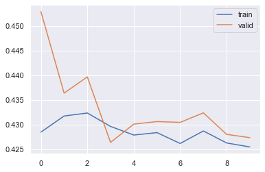

```python
# Capturing learning history per epoch
hist  = pd.DataFrame(history.history)
hist['epoch'] = history.epoch

# Plotting accuracy at different epochs
plt.plot(hist['loss'])
plt.plot(hist['val_loss'])
plt.legend(("train" , "valid") , loc =0)
```

## Model Performance Evaluation (15 points)

- Evaluate the model on different performance metrics and comment on the performance and scope of improvement

**Evaluation**

- Keras model can be evaluated with evaluate() function
- Evaluation results are contained in a list

```python
score = model.evaluate(X_test, y_test)
print(score)
```

```
[0.42031580209732056, 0.8295000195503235]
```

**Let's Print confusion matrix**

```python
def make_confusion_matrix(cf,
                          group_names=None,
                          categories='auto',
                          count=True,
                          percent=True,
                          cbar=True,
                          xyticks=True,
                          xyplotlabels=True,
                          sum_stats=True,
                          figsize=None,
                          cmap='Blues',
                          title=None):
    '''
    This function will make a pretty plot of an sklearn Confusion Matrix cm using a Seaborn heatmap visualization.
    Arguments
    '''


    # CODE TO GENERATE TEXT INSIDE EACH SQUARE
    blanks = ['' for i in range(cf.size)]

    if group_names and len(group_names)==cf.size:
        group_labels = ["{}\n".format(value) for value in group_names]
    else:
        group_labels = blanks

    if count:
        group_counts = ["{0:0.0f}\n".format(value) for value in cf.flatten()]
    else:
        group_counts = blanks

    if percent:
        group_percentages = ["{0:.2%}".format(value) for value in cf.flatten()/np.sum(cf)]
    else:
        group_percentages = blanks

    box_labels = [f"{v1}{v2}{v3}".strip() for v1, v2, v3 in zip(group_labels,group_counts,group_percentages)]
    box_labels = np.asarray(box_labels).reshape(cf.shape[0],cf.shape[1])


    # CODE TO GENERATE SUMMARY STATISTICS & TEXT FOR SUMMARY STATS
    if sum_stats:
        #Accuracy is sum of diagonal divided by total observations
        accuracy  = np.trace(cf) / float(np.sum(cf))

        #if it is a binary confusion matrix, show some more stats
        if len(cf)==2:
            #Metrics for Binary Confusion Matrices
            precision = cf[1,1] / sum(cf[:,1])
            recall    = cf[1,1] / sum(cf[1,:])
            f1_score  = 2*precision*recall / (precision + recall)
            stats_text = "\n\nAccuracy={:0.3f}\nPrecision={:0.3f}\nRecall={:0.3f}\nF1 Score={:0.3f}".format(
                accuracy,precision,recall,f1_score)
        else:
            stats_text = "\n\nAccuracy={:0.3f}".format(accuracy)
    else:
        stats_text = ""


    # SET FIGURE PARAMETERS ACCORDING TO OTHER ARGUMENTS
    if figsize==None:
        #Get default figure size if not set
        figsize = plt.rcParams.get('figure.figsize')

    if xyticks==False:
        #Do not show categories if xyticks is False
        categories=False


    # MAKE THE HEATMAP VISUALIZATION
    plt.figure(figsize=figsize)
    sns.heatmap(cf,annot=box_labels,fmt="",cmap=cmap,cbar=cbar,xticklabels=categories,yticklabels=categories)

    if xyplotlabels:
        plt.ylabel('True label')
        plt.xlabel('Predicted label' + stats_text)
    else:
        plt.xlabel(stats_text)

    if title:
        plt.title(title)
```

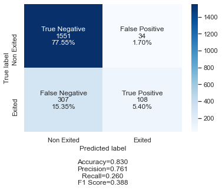

```python
## Confusion Matrix on unsee test set
import seaborn as sn
y_pred1 = model.predict(X_test)
for i in range(len(y_test)):
    if y_pred1[i]>0.5:
        y_pred1[i]=1
    else:
        y_pred1[i]=0



cm2=confusion_matrix(y_test, y_pred1)
labels = ['True Negative','False Positive','False Negative','True Positive']
categories = [ 'Non Exited','Exited']
make_confusion_matrix(cm2,
                      group_names=labels,
                      categories=categories,
                      cmap='Blues')
```

- The model achieves an accuracy of 83.0% and a precision of 76.10%, an acceptable performance to predict the Non Exited customers.
- But the recall is really very low, just the 26%, it means the Exited customers are not well predicted.

## Conclusion and Key Takeaways (5 points)

- Final conclusion about the analysis

As we have found the precision and accuracy are good but the recall is low. There is still lot of scope of improvements as follows:

1) The different parameters can be tuned to get a better optimal value

2) Other models can be build and probed such as a multi-layer perceptron

The Model-1 here presented is good to detect the Non Exited customers but it is weak to detect the Exited customers.